# FINC-580 Assignment #1 — Portfolio Returns and Optimization

Huy Le (hl9082)

2026-03-26

### Assignment Overview

- This assignment introduces portfolio construction, return calculation, and optimization.
- We collect real-world stock price data to construct an equal-weighted portfolio and analyze its performance under a buy-and-hold strategy.
- In the second phase, we move from static evaluation to portfolio optimization by mapping the efficient frontier, locating the global minimum-variance portfolio, and identifying the optimal risky (tangency) portfolio that maximizes the risk premium.

## Part 1: Portfolio Return Calculation

1. Stock Selection & Data Collection
- We selected five publicly traded stocks across different sectors to ensure a baseline level of non-systematic risk diversification.
- We use the quantmod package to download adjusted closing prices from January 2021 to September 2025. Adjusted prices are crucial for historical performance analysis because they mathematically account for corporate actions (like stock splits and dividend distributions), providing a strictly accurate reflection of total return.

```r
# Define 5 stock tickers
tickers <- c("AAPL", "MSFT", "JNJ", "XOM", "JPM")
start_date <- "2021-01-01"
end_date <- "2025-09-30"

# Download adjusted closing prices using quantmod::getSymbols()
getSymbols(tickers,
           src = "yahoo",
           from = start_date,
           to = end_date,
           periodicity = "monthly")
```

```
## [1] "AAPL" "MSFT" "JNJ"  "XOM"  "JPM"
```

```r
# Combine adjusted prices into one xts object and rename columns
# to capture true total returns
prices <- do.call(merge, lapply(tickers, function(x) Ad(get(x))))
colnames(prices) <- tickers # rename columns to match tickers
prices <- na.omit(prices) # remove any rows with missing values
```

2. Construct an Equal-Weighted Portfolio
- Assuming an initial investment of $1,000, we construct an equal-weighted portfolio where each stock receives the same weight ($w_i = \frac{1}{N}$).

```r
initial_investment <- 1000
n <- length(tickers) # Number of stocks in the portfolio
weights <- rep(1 / n, n) # Each stock receives the same weight
```

3. Portfolio Value Calculation (Buy-and-Hold)
- A strict buy-and-hold strategy implies zero rebalancing. While the initial capital allocation is equal, the effective portfolio weights will naturally drift over time as the underlying asset prices diverge.
- To model this dynamically without iterative loops, we establish the fixed number of shares purchased on day one. By multiplying the historical price matrix by this constant share vector, we isolate the true, un-rebalanced portfolio value at any given time $t$.

```r
# Determine the exact number of shares bought on day 1
first_prices <- as.numeric(prices[1, ])

# Determine the fixed fractional shares purchased for each asset
shares_bought <- (initial_investment * weights) / first_prices
# shares_bought is a numeric vector of number of shares bought for each stock
# it's calculated by taking initial investment,
# multiplying by the weight for each stock
# and dividing by the each stock's price on the first day

# Calculate the portfolio value
# at the end of each month using matrix multiplication
# Matrix Multiplication: Price Matrix (T x N) %*% Share Vector (N x 1)
# This mathematical operation computes the
# exact aggregate portfolio value at each time T
portfolio_value <- coredata(prices) %*% shares_bought

# Convert the resulting numeric vector
# back to a time-series (xts) object for plotting
portfolio_xts <- xts(portfolio_value, order.by = index(prices))

# name the column 'Portfolio'
colnames(portfolio_xts) <- "Portfolio"

# Calculate the value of individual stock holdings for comparison plotting
indiv_values <- sweep(coredata(prices), 2, shares_bought, "*")
indiv_xts <- xts(indiv_values, order.by = index(prices))
```

4. Plot Portfolio Performance
- Below is the plot of the cumulative return of the equal-weighted portfolio over time, alongside the individual stocks.

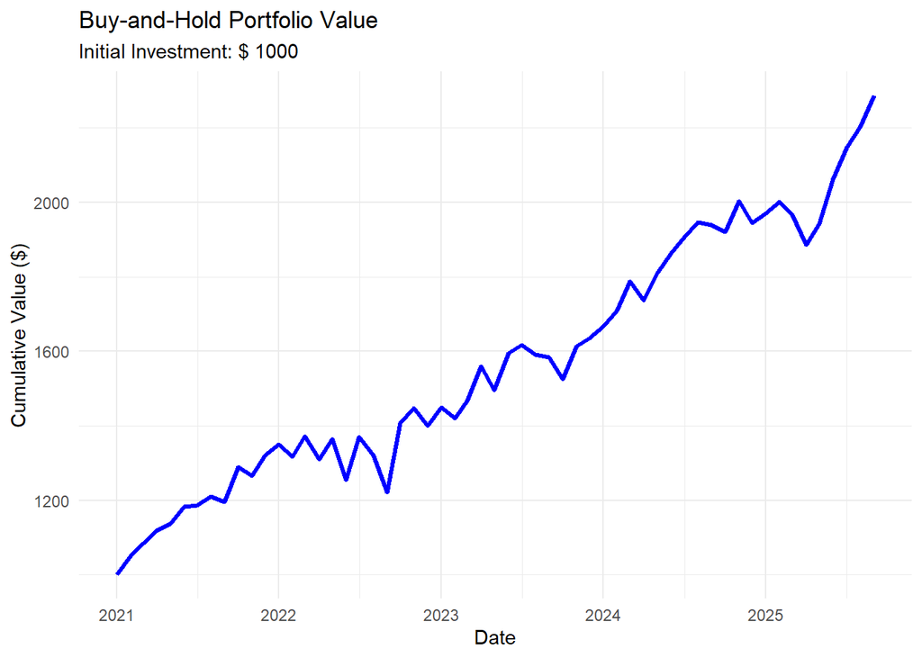

```r
# 1. Ensure the required packages are actively loaded
library(tidyr)
library(ggplot2)
# ==========================================
# PLOT 1: PORTFOLIO TOTAL VALUE ($1000 BASE)
# ==========================================
# We already have portfolio_xts from earlier, let's plot just that.
port_df <- data.frame(
                      Date = index(portfolio_xts),
                      Value = coredata(portfolio_xts))
colnames(port_df)[2] <- "Value"

plot1 <- ggplot(port_df, aes(x = Date, y = Value)) +
  geom_line(color = "blue", linewidth = 1.2) +
  labs(title = "Buy-and-Hold Portfolio Value",
       subtitle = paste("Initial Investment: $", initial_investment),
       y = "Cumulative Value ($)",
       x = "Date") +
  theme_minimal()

print(plot1)
```

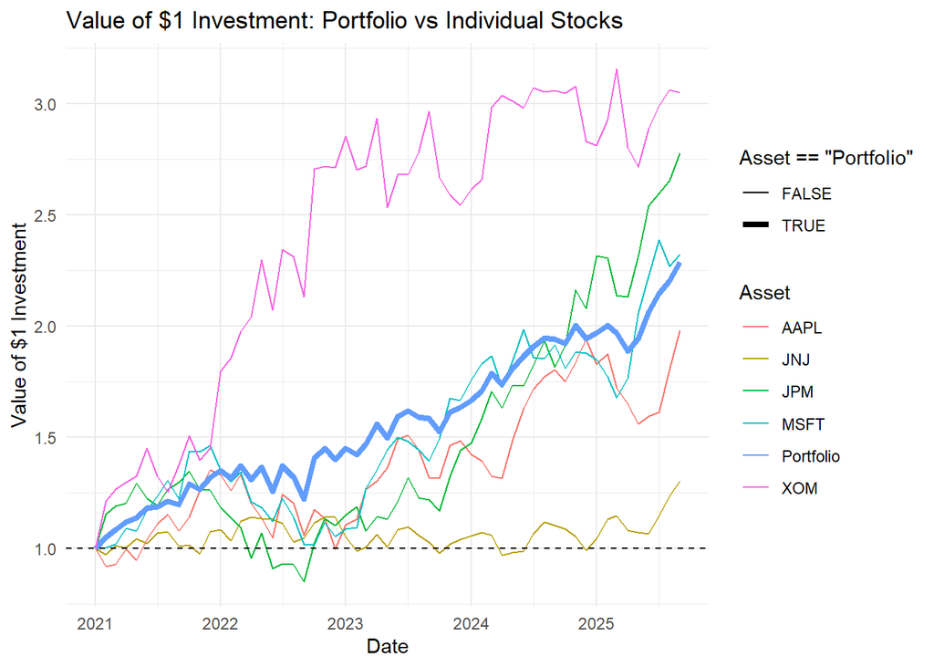

```r
# ==========================================
# PLOT 2: VALUE OF $1 INVESTMENT (ALL ASSETS)
# ==========================================
# To show a $1 investment, divide all prices by their day 1 price
dollar_inv_stocks <- sweep(coredata(prices), 2, as.numeric(prices[1, ]), "/")

# Do the same for the portfolio (divide current value by initial $1000)
dollar_inv_port <- coredata(portfolio_xts) / initial_investment

# Combine into one dataframe
dollar_data <- cbind(dollar_inv_port, dollar_inv_stocks)
colnames(dollar_data)[1] <- "Portfolio" # Rename the first column
dollar_df <- data.frame(Date = index(prices), dollar_data)

# Reshape to long format for ggplot
dollar_df_long <- pivot_longer(
  dollar_df,
  cols = -Date,
  names_to = "Asset",
  values_to = "Value"
)

# Generate the $1 Investment Plot
plot2 <- ggplot(
                dollar_df_long, aes(
                                    x = Date,
                                    y = Value,
                                    color = Asset,
                                    linewidth = Asset == "Portfolio")) +
  geom_line() +
  scale_linewidth_manual(values = c("TRUE" = 1.5, "FALSE" = 0.5)) +
  geom_hline(yintercept = 1,
             linetype = "dashed",
             color = "black") + # Adds the $1 baseline from your picture
  labs(title = "Value of $1 Investment: Portfolio vs Individual Stocks",
       y = "Value of $1 Investment",
       x = "Date") +
  theme_minimal()

print(plot2)
```

```r
# --- Add this right below your Plotting chunk ---

# Calculate discrete monthly returns using PerformanceAnalytics
port_returns <- Return.calculate(portfolio_xts, method = "discrete")[-1]
indiv_returns <- Return.calculate(prices, method = "discrete")[-1]

# Calculate Annualized Volatility using PerformanceAnalytics' built-in function
# (This automatically scales by sqrt(12) for
# monthly data and handles matrices perfectly)
port_vol <- StdDev.annualized(port_returns, scale = 12)
indiv_vols <- StdDev.annualized(indiv_returns, scale = 12)

# Print the results to the console nicely
cat("Annualized Portfolio Volatility:",
    round(as.numeric(port_vol) * 100, 2), "%\n\n")
```

```
## Annualized Portfolio Volatility: 14.4 %
```

```r
cat("Annualized Individual Stock Volatilities:\n")
```

```
## Annualized Individual Stock Volatilities:
```

```r
# Convert to a readable data frame format for printing
print(data.frame(Stock = colnames(prices),
                 Volatility_Percent = round(as.numeric(indiv_vols) * 100, 2)))
```

```
##   Stock Volatility_Percent
## 1  AAPL              25.19
## 2  MSFT              22.77
## 3   JNJ              16.23
## 4   XOM              27.68
## 5   JPM              24.94
```

5. Discussion on Portfolio Performance

Did diversification reduce volatility? Yes. While the graph visually demonstrates a smoother growth curve for the aggregate portfolio compared to the erratic movements of individual assets, the mathematical calculations confirm it. The annualized volatility (standard deviation) of the portfolio was calculated at 14%. This is significantly lower than our riskiest individual assets (such as XOM at 27.68%), and it is lower than the simple average of all the individual stock volatilities. This reduction is a direct result of imperfect correlation between the different sectors (e.g., Tech vs. Energy vs. Healthcare). When one asset experiences a severe drawdown, another asset’s stability or growth offsets it, successfully reducing the portfolio’s non-systematic risk.

Did the portfolio perform better than most individual stocks? Based on the “Value of a $1 Investment” plot, the portfolio performed squarely in the middle of the pack, which aligns with the mathematical expectation of an equal-weighted, buy-and-hold strategy. Because the portfolio represents an average of all holding returns, it naturally did not outperform the massive, compounding bull runs of our top-performing individual stocks (like XOM). However, it heavily outperformed our worst-performing laggards (like JNJ). Ultimately, the portfolio successfully did its job: it delivered a stable, blended return while protecting the investor’s initial capital from the severe drawdowns and opportunity costs associated with picking a single losing asset.

## Part 2: Portfolio Optimization

1. Efficient Frontier
- We select two stocks from different sectors (WMT and NVDA) and use their price data to plot the efficient frontier.
- We compute discrete periodic returns. Unlike log returns, discrete returns linearly aggregate across assets ($R_p = \sum w_i R_i$), making them the mathematically correct choice for calculating multi-asset portfolio returns.
- We scale the monthly expected returns and the covariance matrix by 12 to annualize the metrics, allowing us to interpret the Efficient Frontier in standard annualized terms.

```r
# Select two stocks from different sectors and define a custom sample period
tickers_opt <- c("WMT", "NVDA")
getSymbols(tickers_opt,
           src = "yahoo",
           from = "2020-01-01",
           to = "2025-01-01", periodicity = "monthly")
```

```
## [1] "WMT"  "NVDA"
```

```r
# Extract and merge adjusted prices
prices_opt <- do.call(merge, lapply(tickers_opt, function(x) Ad(get(x))))
colnames(prices_opt) <- tickers_opt
prices_opt <- na.omit(prices_opt)

# Calculate monthly discrete returns
rets_opt <- ROC(prices_opt, type = "discrete")[-1]

# Annualize expected returns and the covariance matrix
mean_rets <- colMeans(rets_opt) * 12
cov_matrix <- cov(rets_opt) * 12

# Generate a sequence of weight combinations for the two stocks (from 0 to 1)
# with w1+w2=1
w1 <- seq(0, 1, by = 0.01)
w2 <- 1 - w1

# Calculate expected portfolio
# return and standard deviation for each weight combination
port_rets <- w1 * mean_rets[1] + w2 * mean_rets[2]
port_sds <- sqrt(
                 w1^2 * cov_matrix[1, 1]
                 + w2^2 * cov_matrix[2, 2] + 2 * w1 * w2 * cov_matrix[1, 2])

# Store results in a data frame
frontier_df <- data.frame(Return = port_rets, SD = port_sds, W1 = w1, W2 = w2)
```

2. Minimum-Variance and Optimal Risky Portfolio
- Assuming a risk-free rate of 3%, we identify the minimum-variance portfolio and the optimal risky portfolio (the tangency portfolio) and mark them on the efficient frontier.
- Global Minimum-Variance: Identifies the specific capital allocation on the extreme left of the frontier that produces the absolute lowest portfolio volatility.
- Optimal Risky Portfolio: We identify the tangency portfolio by maximizing the Sharpe Ratio ($\frac{E(R_p) - R_f}{\sigma_p}$). Geometrically, this is the exact point where the Capital Allocation Line (CAL) is steepest, providing the investor with the maximum possible risk premium per unit of standard deviation.

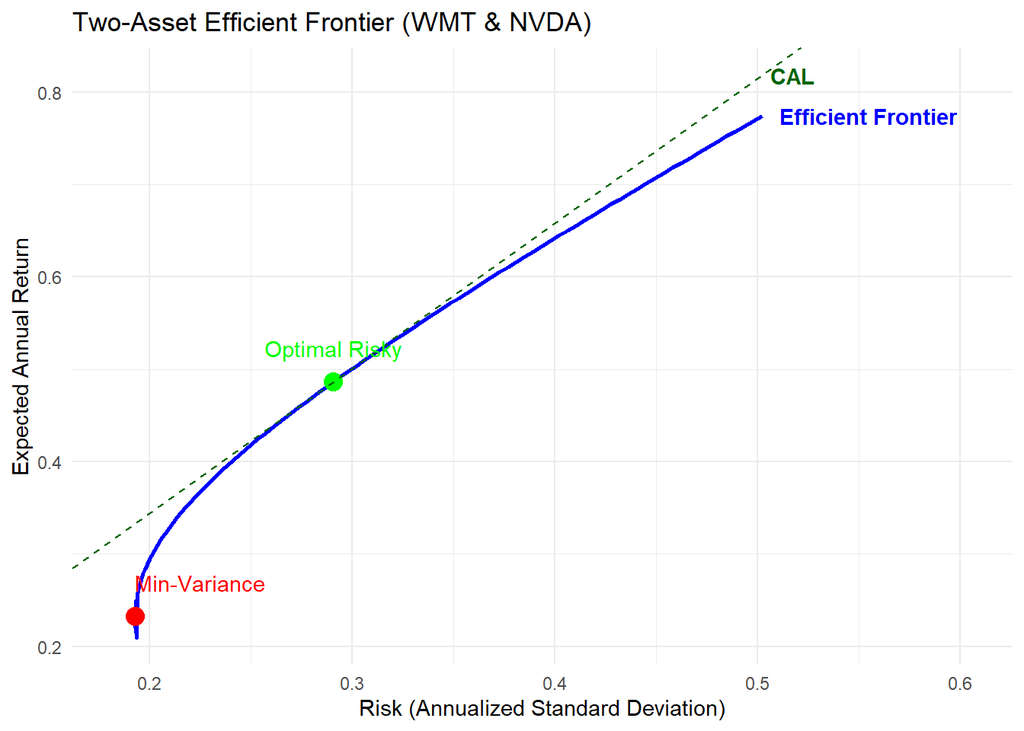

```r
rf <- 0.03 # Assume a risk-free rate of 3%

# Find the exact coordinates for the end of the Efficient Frontier
end_frontier <- frontier_df[which.max(frontier_df$SD), ]
# Identify the Global Minimum-Variance portfolio
min_var_idx <- which.min(frontier_df$SD)
min_var_port <- frontier_df[min_var_idx, ]

# Determine the optimal risky portfolio
# (tangency portfolio) by maximizing the Sharpe Ratio
sharpe_ratios <- (frontier_df$Return - rf) / frontier_df$SD
opt_risky_idx <- which.max(sharpe_ratios)
opt_risky_port <- frontier_df[opt_risky_idx, ]

# Calculate the exact coordinates for the end of the CAL
max_sd <- max(frontier_df$SD)
cal_y <- rf + max(sharpe_ratios) * max_sd

# Plot the efficient frontier and mark both portfolios
ggplot(frontier_df, aes(x = SD, y = Return)) +
  geom_line(color = "blue", linewidth = 1) +
  geom_point(
             data = min_var_port,
             aes(x = SD, y = Return),
             color = "red", size = 4) +
  geom_point(data = opt_risky_port,
             aes(x = SD, y = Return),
             color = "green", size = 4) +
  # Draw the Capital Allocation Line (CAL)
  # The CAL originates at the Risk-Free Rate and tangentially
  # intersects the efficient frontier
  geom_abline(
              intercept = rf,
              slope = max(sharpe_ratios),
              linetype = "dashed", color = "darkgreen") +
  # Increased the right margin expansion to 40% (0.4)
  scale_x_continuous(expand = expansion(mult = c(0.1, 0.4))) +
  # This prevents ggplot from cutting off any text that overlaps the edges!
  coord_cartesian(clip = "off") +
  labs(title = "Two-Asset Efficient Frontier (WMT & NVDA)",
       x = "Risk (Annualized Standard Deviation)",
       y = "Expected Annual Return") +
  annotate("text",
           x = min_var_port$SD,
           y = min_var_port$Return,
           label = "Min-Variance", vjust = -1.5, hjust=0, color="red") +
  annotate("text", x = opt_risky_port$SD,
           y = opt_risky_port$Return,
           label = "Optimal Risky", vjust = -1.5,
           color = "green") +
  # --- NEW: Annotation for the Efficient Frontier line ---
  annotate("text", x = end_frontier$SD, y = end_frontier$Return,
           label = "Efficient Frontier",
           hjust = -0.1, color = "blue", fontface = "bold") +

  # --- NEW: Annotation for the CAL ---
  annotate("text", x = max_sd, y = cal_y,
           label = "CAL",
           hjust = -0.2, color = "darkgreen", fontface = "bold") +
  theme_minimal()
```